# Bilan Qubs

**DATE DE LA DERNIERE SESSION D’OBSERVATION DANS LES DONNEES : 12 June 2026**

## Chiffres clés

**Synthèse sessions**

| Protocole | Sites | Participants | Sessions | Sessions vides |
| --- | --- | --- | --- | --- |
| Aspifaune | 443 | 244 | 1057 | 57 |
| En quête de vers | 55 | 33 | 81 | 14 |
| Noctambules | 197 | 70 | 522 | 77 |
| Opération escargots | 277 | 241 | 776 | 220 |

**Mêmes chiffres déclinés par année**

| Protocole | Année | Sites | Participants | Sessions | Sessions vides |
| --- | --- | --- | --- | --- | --- |
| Aspifaune | 2022 | 19 | 15 | 29 | 1 |
| Aspifaune | 2023 | 111 | 55 | 236 | 11 |
| Aspifaune | 2024 | 137 | 89 | 333 | 7 |
| Aspifaune | 2025 | 97 | 44 | 192 | 16 |
| Aspifaune | 2026 | 89 | 61 | 267 | 22 |
| En quête de vers | 2024 | 20 | 19 | 27 | 2 |
| En quête de vers | 2025 | 30 | 9 | 44 | 10 |
| En quête de vers | 2026 | 8 | 8 | 10 | 2 |
| Noctambules | 2022 | 43 | 11 | 56 | 5 |
| Noctambules | 2023 | 77 | 26 | 170 | 15 |

[output cut: 7 more lines]

**Répartition participants/protocoles**

| Combinaison protocoles | Nombre de sites |
| --- | --- |
| 1 | 853 |
| 2 | 52 |
| 3 | 5 |

**Tableau observations**

| Protocole | Taxons Qubs différents | Organismes identifiés | Organismes non identifiés | Pourcentage identifications validées | Nombre de photos |
| --- | --- | --- | --- | --- | --- |
| Aspifaune | 271 | 2953 | 399 | 36.22 | 3162 |
| En quête de vers | 29 | 128 | 39 | 10.78 | 168 |
| Noctambules | 168 | 1201 | 78 | 50.9 | 1269 |
| Opération escargots | 31 | 1388 | 240 | 37.47 | 1865 |

**Mêmes chiffres déclinés par année**

| Protocole | Année | Taxons Qubs différents | Organismes identifiés | Organismes non identifiés | Pourcentage identifications validées | Nombre de photos |
| --- | --- | --- | --- | --- | --- | --- |
| Aspifaune | 2022 | 59 | 141 | 9 | 89.33 | 142 |
| Aspifaune | 2023 | 155 | 748 | 78 | 61.38 | 773 |
| Aspifaune | 2024 | 182 | 1087 | 144 | 36.39 | 1161 |
| Aspifaune | 2025 | 121 | 470 | 77 | 19.93 | 521 |
| Aspifaune | 2026 | 129 | 507 | 91 | 2.68 | 564 |
| En quête de vers | 2024 | 21 | 46 | 31 | 6.49 | 77 |
| En quête de vers | 2025 | 17 | 67 | 5 | 18.06 | 72 |
| En quête de vers | 2026 | 10 | 15 | 3 | 0 | 18 |
| Noctambules | 2022 | 40 | 151 | 6 | 91.08 | 157 |
| Noctambules | 2023 | 111 | 438 | 25 | 64.79 | 461 |

[output cut: 7 more lines]

## Types de sites

La figure ci-dessous présente la distribution des sessions d’observation suivant le type de site. Les résultats sont déclinés par protocole, et représentés en proportion de l’ensemble des sessions d’observation.

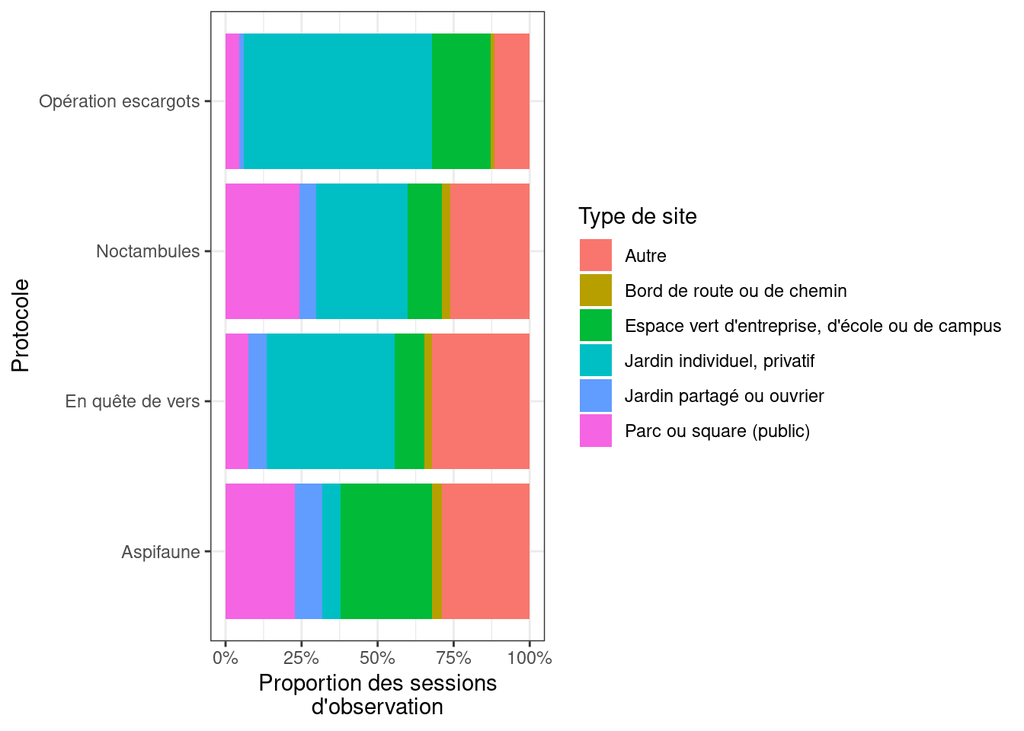

**Chiffres associés**

| Protocole | Type de site | Nombre de sessions |
| --- | --- | --- |
| Aspifaune | Autre | 302 |
| Aspifaune | Bord de route ou de chemin | 33 |
| Aspifaune | Espace vert d'entreprise, d'école ou de campus | 318 |
| Aspifaune | Jardin individuel, privatif | 63 |
| Aspifaune | Jardin partagé ou ouvrier | 97 |
| Aspifaune | Parc ou square (public) | 240 |
| Aspifaune | Site d'activité maraichère | 4 |
| En quête de vers | Autre | 26 |
| En quête de vers | Bord de route ou de chemin | 2 |
| En quête de vers | Espace vert d'entreprise, d'école ou de campus | 8 |

[output cut: 16 more lines]

## Stats spéciales par protocole

**Aspifaune**

Dans le cadre du protocole Aspifaune on totalise 66.0625 m² de surface totale aspirée !

**Noctambules**

Dans le cadre du protocole Noctambules on peut fournir la durée totale de pose des gobelets la nuit : 9635.86666666667 heures.

Sinon je trouve que c’est plus parlant de donner le nombre de nuits différentes échantillonnées : 182 nuits échantillonnées depuis le lancement.

**Opération escargots**

- Nombre total d’individus observés : 4114
- Nombre de taxons différents observés : 31
- Nombre de taxons différents observés et validés : 20
- Nombre d’abris : 277 (124 Coupelles ; 153 Planches)

**En quête de vers**

Dans le cadre du protocole En quête de vers on totalise 810 litres de sol trié !

## Communauté Qubs

**Intractions au total**

Ce tableau donne pour chaque protocole le **nombre total** de validations, de suggestions, de ré-identifications et de commentaires sur participations.

| Protocole | Validations | Suggestions | Ré-identifications | Commentaires session |
| --- | --- | --- | --- | --- |
| Aspifaune | 4101 | 1402 | 835 | 1073 |
| En quête de vers | 69 | 26 | 38 | 40 |
| Noctambules | 2262 | 564 | 210 | 603 |
| Opération escargots | 1634 | 279 | 42 | 533 |

**Participant.es impliqués**

Ce tableau donne pour chaque protocole le **nombre de participant.es** ayant fait des validations, des suggestions, des ré-identifications ou des commentaires sur participation

| Protocole | Validations | Suggestions | Ré-identifications | Commentaires session |
| --- | --- | --- | --- | --- |
| Aspifaune | 70 | 54 | 77 | 33 |
| En quête de vers | 14 | 7 | 6 | 7 |
| Noctambules | 49 | 31 | 22 | 25 |
| Opération escargots | 45 | 32 | 15 | 22 |

## Suggestions en attente

Le tableau ci-dessous fournit pour chaque protocole le nombre d’observations avec une suggestion d’identification en attente. Ce nombre de suggestions en attente peut être comparé au total des observations pour chaque protocole.

| Protocole | Suggestions en attente | Total observations | Pourcentage |
| --- | --- | --- | --- |
| Aspifaune | 586 | 3178 | 18.44 |
| En quête de vers | 11 | 168 | 6.55 |
| Noctambules | 279 | 1269 | 21.99 |
| Opération escargots | 212 | 981 | 21.61 |

## Top taxons

**Top taxons validés**

Le tableau ci-dessous fournit, pour chaque taxon de la clé Qubs et pour chaque protocole, le nombre d’identifications validées. Petites précisions :

- Si le chiffre est égal à zéro : le taxon a été identifié dans le cadre du protocole mais n’a pas encore été validé
- Si la case est vide (NA) : le taxon n’a pas été identifié dans le cadre du protocole

[output not shown]

[output cut: 293 more lines]

**Top taxons tout compris**

Le tableau ci-dessous fournit, pour chaque taxon de la clé Qubs et pour chaque protocole, le nombre d’observations sans prendre en compte la validation. Si la case est vide alors le taxon n’a pas été observé dans le cadre du protocole.

| taxon | Noctambules | Aspifaune | Opération escargots | En quête de vers |
| --- | --- | --- | --- | --- |
| L'Amphipode des pelouses | 2 |  |  |  |
| L'Anchomène des champs | 1 |  |  |  |
| L'Araignée crabe Ebrechtella | 1 |  |  |  |
| L'Araignée crabe Napoléon |  | 1 |  |  |
| L'Araignée crabe Runcinia | 1 |  |  |  |
| L'Armadille commune | 9 | 8 |  |  |
| L'Armadille granulée |  | 1 |  |  |
| L'Armadille à long museau | 13 | 13 |  |  |
| L'Aselle des murs | 4 | 9 |  |  |
| L'Elégante striée | 1 | 36 | 41 |  |

[output cut: 293 more lines]

## Camemberts taxo

Cette partie fournit l’information sur la distribution des observations (occurrence) selon différents regroupements d’espèces. Les proportions sont calculées à partir de l’ensemble des observations (sans prendre en compte la validation)

Pour Aspifaune, Noctambules et l’ensemble des données Qubs, sont fournis un donut chart de la distribution des observations en 7 groupes, un tableau des données associées (Regroupement 2a) puis un tableau de la distribution des observations en 12 groupes.

Pour Opération escargots : la distribution des observations entre escargots et limaces.

**Qubs**

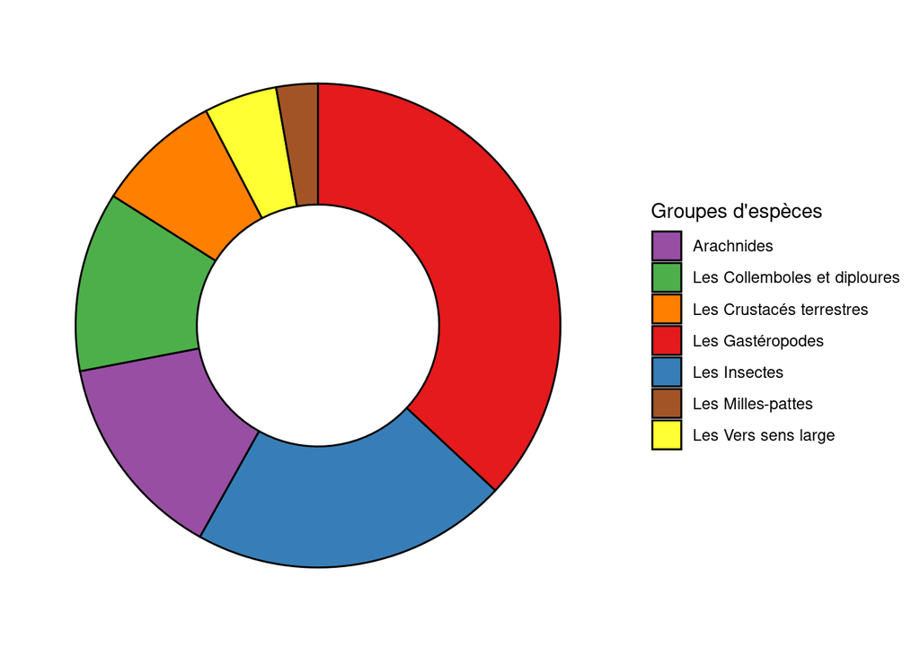

| Regroupement2a | Observations | Observations validées | Proportion groupe |
| --- | --- | --- | --- |
| Les Gastéropodes | 2026 | 873 | 0.369 |
| Les Insectes | 1160 | 498 | 0.212 |
| Arachnides | 761 | 303 | 0.139 |
| Les Collemboles et diploures | 659 | 365 | 0.12 |
| Les Crustacés terrestres | 459 | 201 | 0.084 |
| Les Vers sens large | 267 | 59 | 0.049 |
| Les Milles-pattes | 152 | 85 | 0.028 |

| Regroupement2b | Observations | Observations validées | Proportion groupe |
| --- | --- | --- | --- |
| Les Escargots | 1624 | 760 | 0.286 |
| Les Collemboles et diploures | 659 | 365 | 0.116 |
| Les Araignées | 569 | 198 | 0.1 |
| Les Autres insectes | 471 | 220 | 0.083 |
| Les Crustacés | 459 | 201 | 0.081 |
| Les Fourmis | 406 | 106 | 0.072 |
| Les Limaces | 402 | 113 | 0.071 |
| Les Carabes et Staphylins | 283 | 172 | 0.05 |
| Les Annélides | 264 | 59 | 0.047 |
|  | 186 | 79 | 0.033 |

[output cut: 4 more lines]

**Aspifaune**

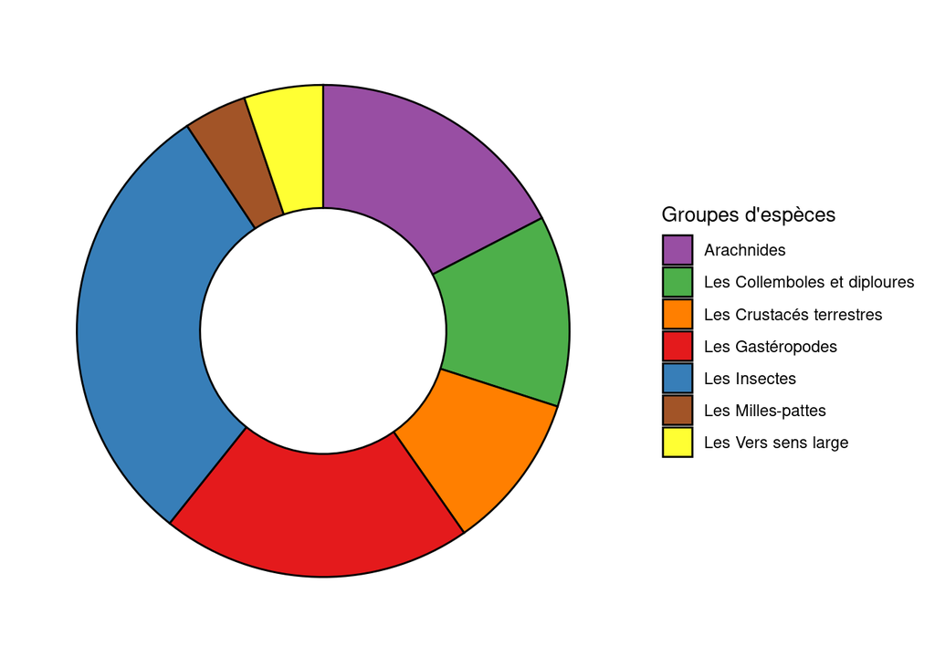

| Regroupement2a | Observations | Observations validées | Proportion groupe |
| --- | --- | --- | --- |
| Arachnides | 493 | 188 | 0.174 |
| Les Collemboles et diploures | 356 | 179 | 0.126 |
| Les Crustacés terrestres | 293 | 118 | 0.103 |
| Les Gastéropodes | 578 | 229 | 0.204 |
| Les Insectes | 849 | 322 | 0.3 |
| Les Milles-pattes | 117 | 66 | 0.041 |
| Les Vers sens large | 147 | 43 | 0.052 |

| Regroupement2b | Observations | Observations validées | Proportion groupe |
| --- | --- | --- | --- |
| Les Escargots | 438 | 169 | 0.148 |
| Les Autres insectes | 390 | 178 | 0.132 |
| Les Collemboles et diploures | 356 | 179 | 0.121 |
| Les Araignées | 355 | 128 | 0.12 |
| Les Fourmis | 344 | 85 | 0.116 |
| Les Crustacés | 293 | 118 | 0.099 |
| Les Annélides | 145 | 43 | 0.049 |
| Les Limaces | 140 | 60 | 0.047 |
|  | 120 | 48 | 0.041 |
| Les Acariens | 118 | 47 | 0.04 |

[output cut: 4 more lines]

**Noctambules**

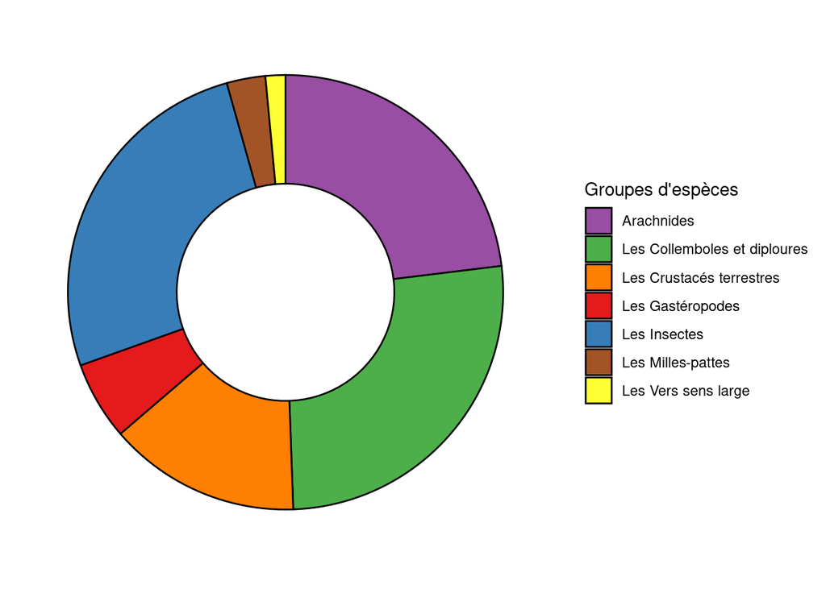

| Regroupement2a | Observations | Observations validées | Proportion groupe |
| --- | --- | --- | --- |
| Arachnides | 265 | 115 | 0.231 |
| Les Collemboles et diploures | 303 | 186 | 0.264 |
| Les Crustacés terrestres | 164 | 83 | 0.143 |
| Les Gastéropodes | 67 | 34 | 0.058 |
| Les Insectes | 300 | 173 | 0.261 |
| Les Milles-pattes | 33 | 19 | 0.029 |
| Les Vers sens large | 17 | 3 | 0.015 |

| Regroupement2b | Observations | Observations validées | Proportion groupe |
| --- | --- | --- | --- |
| Les Collemboles et diploures | 303 | 186 | 0.252 |
| Les Araignées | 211 | 70 | 0.176 |
| Les Carabes et Staphylins | 168 | 113 | 0.14 |
| Les Crustacés | 164 | 83 | 0.137 |
| Les Autres insectes | 70 | 39 | 0.058 |
| Les Fourmis | 62 | 21 | 0.052 |
|  | 52 | 29 | 0.043 |
| Les Limaces | 45 | 25 | 0.037 |
| Les Acariens | 39 | 32 | 0.032 |
| Les Milles-pattes | 33 | 19 | 0.027 |

[output cut: 4 more lines]

**Opération escargots**

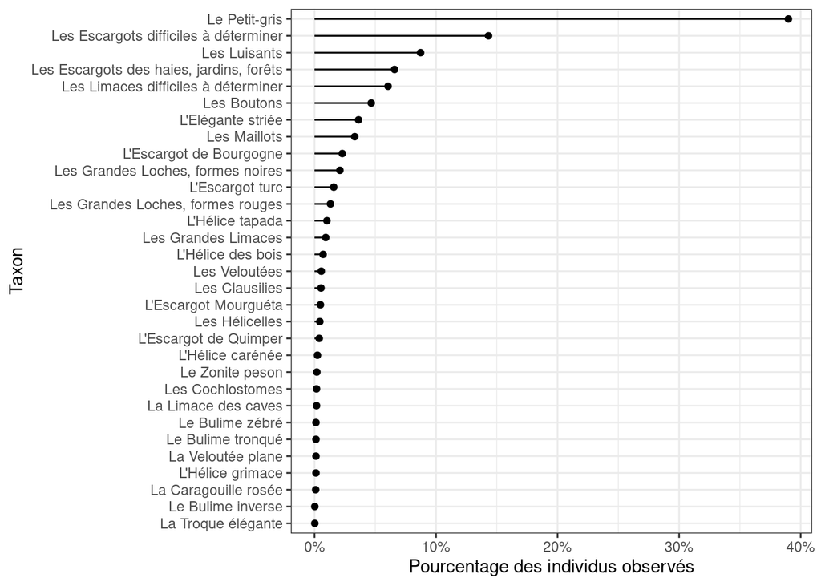

**Valeurs associées à la figure**

| Nom du taxon | Pourcentage de l'abondance totale |
| --- | --- |
| Le Petit-gris | 38.989 |
| Les Escargots difficiles à déterminer | 14.317 |
| Les Luisants | 8.726 |
| Les Escargots des haies, jardins, forêts | 6.587 |
| Les Limaces difficiles à déterminer | 6.053 |
| Les Boutons | 4.667 |
| L'Elégante striée | 3.622 |
| Les Maillots | 3.306 |
| L'Escargot de Bourgogne | 2.285 |
| Les Grandes Loches, formes noires | 2.09 |

[output cut: 21 more lines]

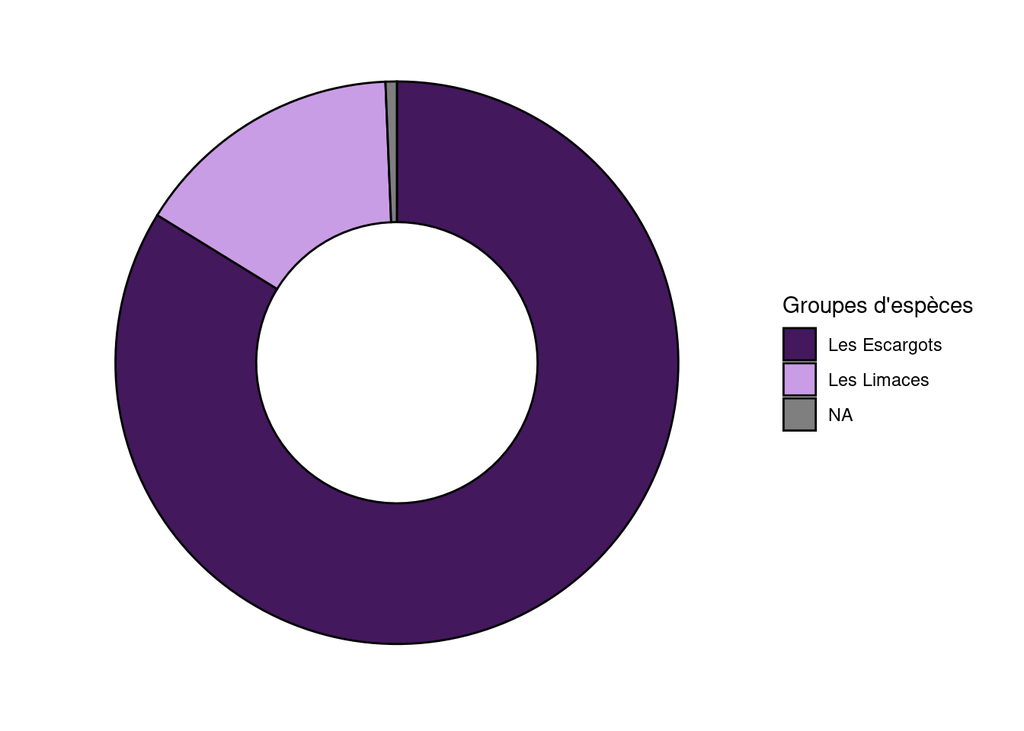

| Regroupement2b | Observations | Observations validées | Proportion groupe |
| --- | --- | --- | --- |
| Les Escargots | 1163 | 582 | 0.838 |
| Les Limaces | 216 | 28 | 0.156 |
|  | 9 | 0 | 0.006 |

**En quête de vers**

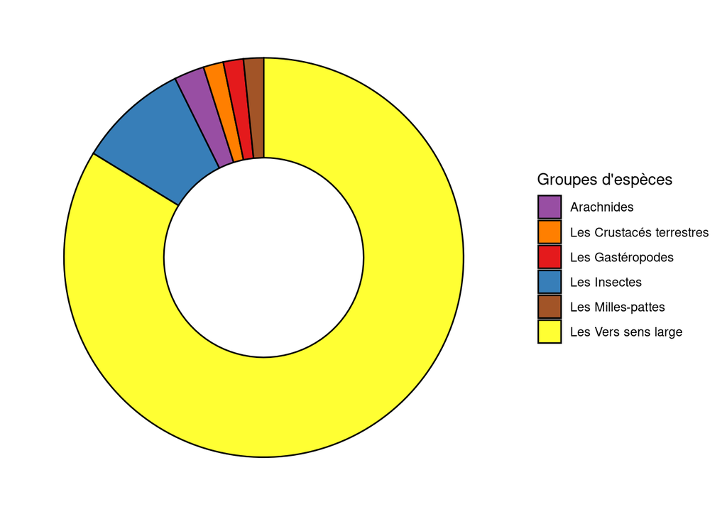

| Regroupement2a | Observations | Observations validées | Proportion groupe |
| --- | --- | --- | --- |
| Les Vers sens large | 103 | 13 | 0.837 |
| Les Insectes | 11 | 3 | 0.089 |
| Arachnides | 3 | 0 | 0.024 |
| Les Crustacés terrestres | 2 | 0 | 0.016 |
| Les Gastéropodes | 2 | 0 | 0.016 |
| Les Milles-pattes | 2 | 0 | 0.016 |

| Regroupement2b | Observations | Observations validées | Proportion groupe |
| --- | --- | --- | --- |
| Les Annélides | 103 | 13 | 0.805 |
| Les Autres insectes | 11 | 3 | 0.086 |
|  | 5 | 2 | 0.039 |
| Les Araignées | 3 | 0 | 0.023 |
| Les Crustacés | 2 | 0 | 0.016 |
| Les Milles-pattes | 2 | 0 | 0.016 |
| Les Escargots | 1 | 0 | 0.008 |
| Les Limaces | 1 | 0 | 0.008 |

## Carte des sites

Une carte simplifiée avec l’ensemble des sites d’échantillonnages (tous protocoles confondus).

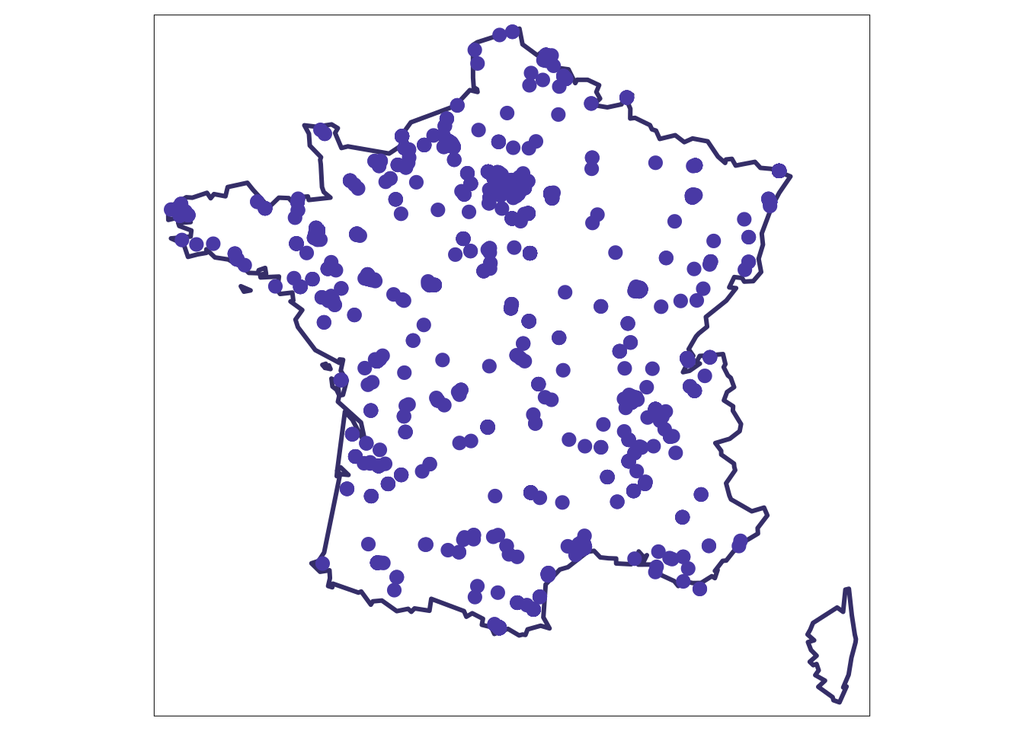

## Cartes des sites par protocole

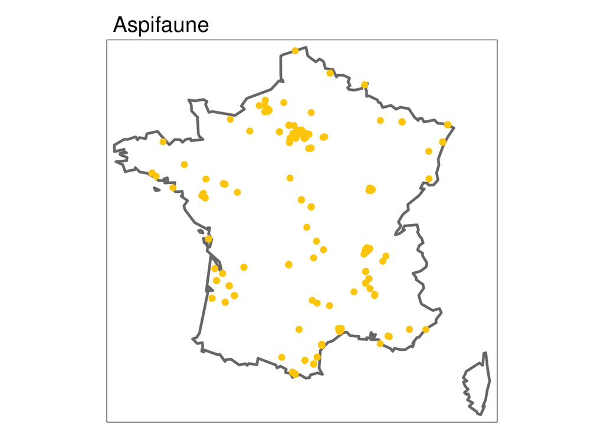

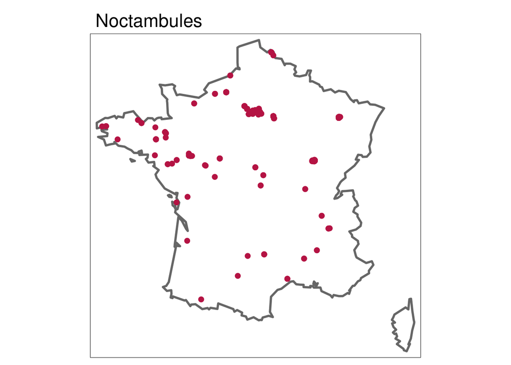

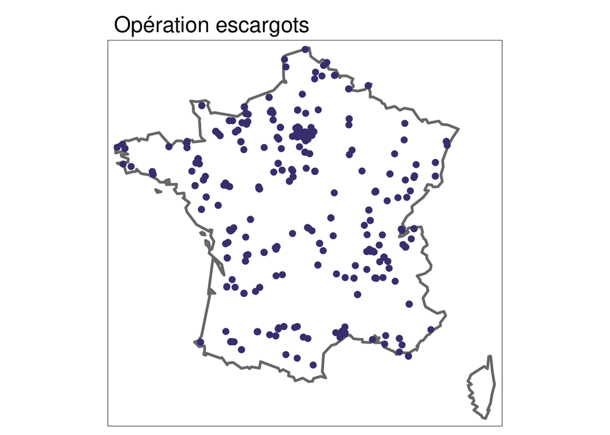

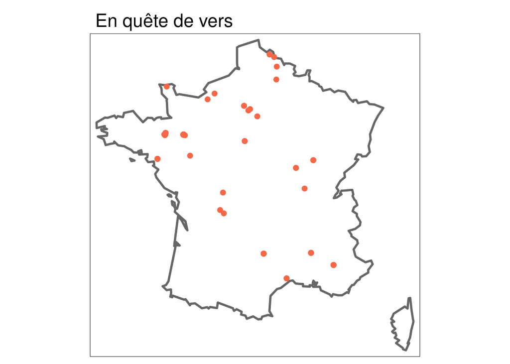